# Failures_analysis

Diego de Lima

April 1st, 2019

## Loading the packages

```r
library(readxl)
library(dplyr)
library(ggplot2)
library(data.table)
library(gridExtra)
library(rlang)
library(stringr)
library(knitr)
library(kableExtra)
```

## Loading the file

```r
# Checking the sheets
excel_sheets('failures.xlsm')
```

```
## [1] "FAILURES"   "ORDERS"     "PRODUCTION"
```

```r
# Failures
failures <- read_excel('failures.xlsm', sheet = 'FAILURES', skip = 2)
production <- read_excel('failures.xlsm', sheet = 'PRODUCTION', skip = 2)
```

## Preparing the dataset

```r
# Checking the type of variables
str(failures)
```

```
## Classes 'tbl_df', 'tbl' and 'data.frame':    676 obs. of  45 variables:
##  $ ORDER    : chr  "095598.AA" "095598.AA" "095598.AA" "095598.AA" ...
##  $ ID       : chr  "10-2092/90D" "10-2084/90C" "10-2084/90B" "10-2081/02C" ...
##  $ LENGTH   : num  222 202 202 202 204 202 202 202 202 102 ...
##  $ MACHINE  : chr  "BA_12" "BA_15" "BA_15" "BA_04" ...
##  $ DATE     : POSIXct, format: "2018-12-04" "2018-12-04" ...
##  $ 1        : logi  NA NA NA NA NA NA ...
##  $ 2        : chr  "22" NA NA NA ...
##  $ 3        : chr  NA NA NA NA ...
##  $ 4        : chr  "95, 120, 124" "152" NA NA ...
##  $ 5        : chr  NA NA "135" NA ...
##  $ 6        : chr  NA NA NA NA ...
##  $ 7        : chr  NA NA NA NA ...
##  $ 8        : chr  NA NA NA NA ...
##  $ 9        : chr  NA NA NA NA ...
```

[output cut: 31 more lines]

```r
# Setting failures$MACHINE as categorical
failures$MACHINE <- as.factor(failures$MACHINE)

# Setting production$MACHINE and production$VERSION as categorical
production$MACHINE <- as.factor(production$MACHINE)
# Replacing VERSION NAs with 0
production$VERSION[is.na(production$VERSION)] <- 0
production$VERSION <- as.factor(production$VERSION)
# Setting 0 as BEFORE and 1 as AFTER
levels(production$VERSION) <- c('BEFORE', 'AFTER')

# Standardizing IDs of the failures set
head(production$ID)
```

```
## [1] "10-2754/91" "10-2737/91" "10-2743/90" "10-2759/90" "10-2736/91"
## [6] "10-2758/90"
```

```r
head(failures$ID)
```

```
## [1] "10-2092/90D" "10-2084/90C" "10-2084/90B" "10-2081/02C" "10-2066/91D"
## [6] "10-2066/91C"
```

```r
# To standardize the ID of failures set, it's only needed to remove the letter from the end of the ID
failures_original <- failures
failures$ID <- gsub('\\D$', '', failures$ID)
```

## PERFOMANCE ANALYSES

Considering that the current situation regards to the failures of a production, it’s important to consider relational metrics intead of absolute: Perfomance instead of Production or Failures.  
The performance metric that will be chosen is an adaptation of MTBF (Mean Tima Between Failures) concept.  
For this project the performance will be measure by: Produced Length Between Failures.  
To be able to calculate this performance, it’s important to discard failures registers that don’t have production registers.

## Removing registers from the failures set which don’t have production registers.

```r
registers <- as.vector(unlist(production$ID))
failures <- failures %>% filter(ID %in% registers)
```

## Merging productions and failures data sets by ID

```r
colnames(failures)
```

```
##  [1] "ORDER"     "ID"        "LENGTH"    "MACHINE"   "DATE"
##  [6] "1"         "2"         "3"         "4"         "5"
## [11] "6"         "7"         "8"         "9"         "10"
## [16] "11"        "12"        "13"        "14"        "15"
## [21] "16"        "17"        "18"        "19_NOTES"  "19_LENGTH"
## [26] "1_"        "2_"        "3_"        "4_"        "5_"
## [31] "6_"        "7_"        "8_"        "9_"        "10_"
## [36] "11_"       "12_"       "13_"       "14_"       "15_"
## [41] "16_"       "17_"       "18_"       "19_"       "TOTAL"
```

```r
production_failures <- merge(production, failures[, c(2, 6:45)], by = 'ID', all = T)
kable(head(production_failures, 10)) %>%
  kable_styling(bootstrap_options = c('striped', 'hover', 'condensed'),
                font_size = 9)
```

| ID | ORDER | PRODUCT | MACHINE | DATE | LENGTH | VERSION | 1 | 2 | 3 | 4 | 5 | 6 | 7 | 8 | 9 | 10 | 11 | 12 | 13 | 14 | 15 | 16 | 17 | 18 | 19_NOTES | 19_LENGTH | 1_ | 2_ | 3_ | … |
| --- | --- | --- | --- | --- | --- | --- | --- | --- | --- | --- | --- | --- | --- | --- | --- | --- | --- | --- | --- | --- | --- | --- | --- | --- | --- | --- | --- | --- | --- | --- |
| 10-0650/90 | 091284.AA | TYPE A | BA_12 | 2018-04-27 | 808 | BEFORE | NA | NA | NA | NA | NA | NA | NA | NA | NA | NA | NA | NA | NA | NA | NA | NA | NA | NA | NA | NA | NA | NA | NA | … |
| 10-2019/91 | 094011.AA | TYPE B | CA_13 | 2018-12-03 | 1075 | BEFORE | NA | NA | NA | 93 | NA | NA | NA | NA | NA | NA | NA | NA | NA | NA | NA | NA | NA | NA | NA | NA | NA | NA | NA | … |
| 10-2019/91 | 094011.AA | TYPE B | CA_13 | 2018-12-03 | 1075 | BEFORE | NA | 24 | NA | NA | NA | NA | NA | NA | NA | NA | NA | NA | NA | NA | NA | NA | 22, 75 | NA | NA | NA | NA | 1 | NA | … |
| 10-2019/91 | 094011.AA | TYPE B | CA_13 | 2018-12-03 | 1075 | BEFORE | NA | NA | NA | 88 | 62 | NA | NA | NA | NA | NA | NA | NA | NA | NA | NA | NA | 8 | NA | NA | NA | NA | NA | NA | … |
| 10-2019/91 | 094011.AA | TYPE B | CA_13 | 2018-12-03 | 1075 | BEFORE | NA | NA | NA | NA | NA | NA | NA | NA | NA | NA | NA | NA | NA | NA | NA | NA | 66 | NA | NA | NA | NA | NA | NA | … |
| 10-2019/91 | 094011.AA | TYPE B | CA_13 | 2018-12-03 | 1075 | BEFORE | NA | NA | NA | NA | 94 | NA | NA | NA | NA | NA | NA | NA | NA | NA | NA | NA | 13 | NA | NA | NA | NA | NA | NA | … |
| 10-2090/91 | 095598.AA | TYPE A | BA_10 | 2018-12-04 | 797 | BEFORE | NA | NA | NA | 48, 64 A 78, 83, 85, 144 | NA | NA | NA | NA | NA | NA | NA | NA | NA | NA | NA | NA | NA | NA | NA | NA | NA | NA | NA | … |
| 10-2090/91 | 095598.AA | TYPE A | BA_10 | 2018-12-04 | 797 | BEFORE | NA | NA | NA | 159 | NA | NA | NA | NA | NA | NA | NA | NA | NA | NA | NA | NA | NA | NA | NA | NA | NA | NA | NA | … |
| 10-2092/91 | 095598.AA | TYPE A | BA_12 | 2018-12-05 | 784 | BEFORE | NA | NA | NA | NA | NA | NA | NA | NA | NA | NA | NA | NA | NA | NA | NA | 43 | NA | NA | NA | NA | NA | NA | NA | … |
| 10-2092/91 | 095598.AA | TYPE A | BA_12 | 2018-12-05 | 784 | BEFORE | NA | NA | NA | 20, 26, 34 | NA | NA | NA | NA | NA | NA | NA | NA | NA | NA | NA | NA | NA | NA | NA | NA | NA | NA | NA | … |

```r
colnames(production_failures)
```

```
##  [1] "ID"        "ORDER"     "PRODUCT"   "MACHINE"   "DATE"
##  [6] "LENGTH"    "VERSION"   "1"         "2"         "3"
## [11] "4"         "5"         "6"         "7"         "8"
## [16] "9"         "10"        "11"        "12"        "13"
## [21] "14"        "15"        "16"        "17"        "18"
## [26] "19_NOTES"  "19_LENGTH" "1_"        "2_"        "3_"
## [31] "4_"        "5_"        "6_"        "7_"        "8_"
## [36] "9_"        "10_"       "11_"       "12_"       "13_"
## [41] "14_"       "15_"       "16_"       "17_"       "18_"
## [46] "19_"       "TOTAL"
```

```r
production_failures[, c(29:47)][is.na(production_failures[, c(29:47)])] <- 0
kable(head(production_failures, 10)) %>%
  kable_styling(bootstrap_options = c('striped', 'hover', 'condensed'),
                font_size = 9)
```

[output not shown]

## Calculating the performance

```r
production_failures <- production_failures %>%
  mutate(PERFORMANCE = if_else(TOTAL == 0, LENGTH, LENGTH / TOTAL))
kable(head(production_failures, 10)) %>%
  kable_styling(bootstrap_options = c('striped', 'hover', 'condensed'),
                font_size = 9)
```

| ID | ORDER | PRODUCT | MACHINE | DATE | LENGTH | VERSION | 1 | 2 | 3 | 4 | 5 | 6 | 7 | 8 | 9 | 10 | 11 | 12 | 13 | 14 | 15 | 16 | 17 | 18 | 19_NOTES | 19_LENGTH | 1_ | 2_ | 3_ | … |
| --- | --- | --- | --- | --- | --- | --- | --- | --- | --- | --- | --- | --- | --- | --- | --- | --- | --- | --- | --- | --- | --- | --- | --- | --- | --- | --- | --- | --- | --- | --- |
| 10-0650/90 | 091284.AA | TYPE A | BA_12 | 2018-04-27 | 808 | BEFORE | NA | NA | NA | NA | NA | NA | NA | NA | NA | NA | NA | NA | NA | NA | NA | NA | NA | NA | NA | NA | NA | 0 | 0 | … |
| 10-2019/91 | 094011.AA | TYPE B | CA_13 | 2018-12-03 | 1075 | BEFORE | NA | NA | NA | 93 | NA | NA | NA | NA | NA | NA | NA | NA | NA | NA | NA | NA | NA | NA | NA | NA | NA | 0 | 0 | … |
| 10-2019/91 | 094011.AA | TYPE B | CA_13 | 2018-12-03 | 1075 | BEFORE | NA | 24 | NA | NA | NA | NA | NA | NA | NA | NA | NA | NA | NA | NA | NA | NA | 22, 75 | NA | NA | NA | NA | 1 | 0 | … |
| 10-2019/91 | 094011.AA | TYPE B | CA_13 | 2018-12-03 | 1075 | BEFORE | NA | NA | NA | 88 | 62 | NA | NA | NA | NA | NA | NA | NA | NA | NA | NA | NA | 8 | NA | NA | NA | NA | 0 | 0 | … |
| 10-2019/91 | 094011.AA | TYPE B | CA_13 | 2018-12-03 | 1075 | BEFORE | NA | NA | NA | NA | NA | NA | NA | NA | NA | NA | NA | NA | NA | NA | NA | NA | 66 | NA | NA | NA | NA | 0 | 0 | … |
| 10-2019/91 | 094011.AA | TYPE B | CA_13 | 2018-12-03 | 1075 | BEFORE | NA | NA | NA | NA | 94 | NA | NA | NA | NA | NA | NA | NA | NA | NA | NA | NA | 13 | NA | NA | NA | NA | 0 | 0 | … |
| 10-2090/91 | 095598.AA | TYPE A | BA_10 | 2018-12-04 | 797 | BEFORE | NA | NA | NA | 48, 64 A 78, 83, 85, 144 | NA | NA | NA | NA | NA | NA | NA | NA | NA | NA | NA | NA | NA | NA | NA | NA | NA | 0 | 0 | … |
| 10-2090/91 | 095598.AA | TYPE A | BA_10 | 2018-12-04 | 797 | BEFORE | NA | NA | NA | 159 | NA | NA | NA | NA | NA | NA | NA | NA | NA | NA | NA | NA | NA | NA | NA | NA | NA | 0 | 0 | … |
| 10-2092/91 | 095598.AA | TYPE A | BA_12 | 2018-12-05 | 784 | BEFORE | NA | NA | NA | NA | NA | NA | NA | NA | NA | NA | NA | NA | NA | NA | NA | 43 | NA | NA | NA | NA | NA | 0 | 0 | … |
| 10-2092/91 | 095598.AA | TYPE A | BA_12 | 2018-12-05 | 784 | BEFORE | NA | NA | NA | 20, 26, 34 | NA | NA | NA | NA | NA | NA | NA | NA | NA | NA | NA | NA | NA | NA | NA | NA | NA | 0 | 0 | … |

## Checking the occurrences of each failure before the changes

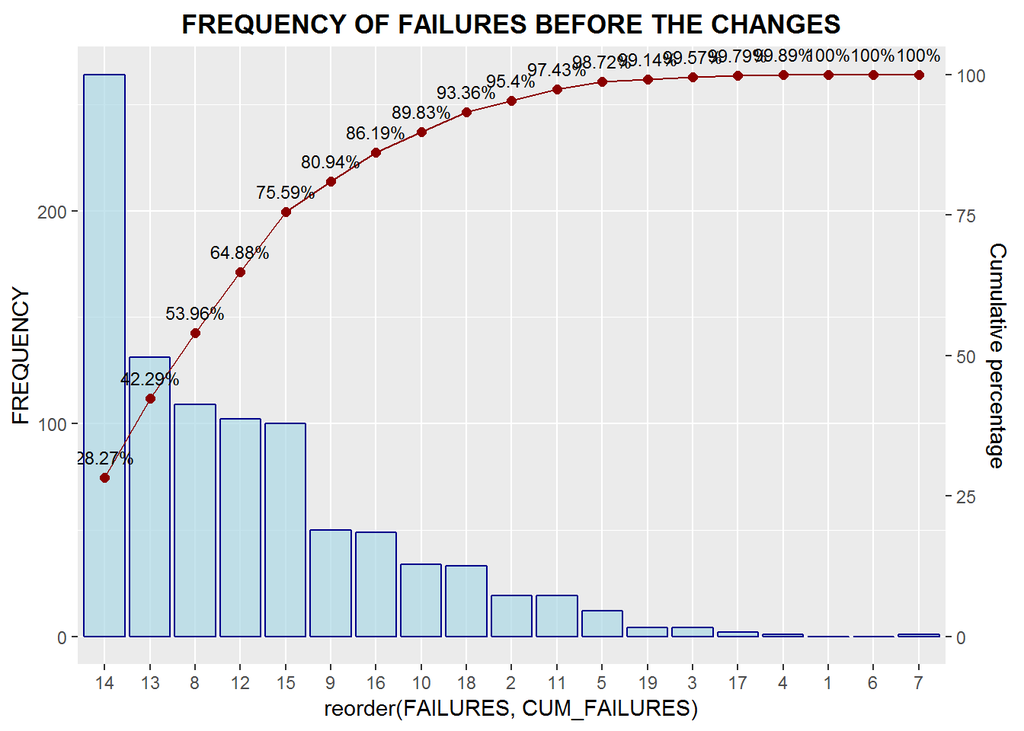

```r
num_failures_before = production_failures[, c(7, 28:46)] %>% filter(VERSION == 'BEFORE')
num_failures_before[is.na(num_failures_before)] <- 0
num_failures_before <- num_failures_before[, -1]
num_failures_before <- data.frame(cbind(
  FAILURES = as.factor(gsub('_', '', colnames(production_failures[, c(28:46)]))),
  FREQUENCY = apply(num_failures_before, 2, sum)))
num_failures_before <- num_failures_before[order(-num_failures_before$FREQUENCY),]
num_failures_before <- num_failures_before %>% mutate(
  CUM_FAILURES = cumsum(FREQUENCY),
  CUM_PERC = round((CUM_FAILURES / sum(FREQUENCY) * 100), 2)
)

# Plotting the occurrences
ggplot(num_failures_before, aes(x = reorder(FAILURES, CUM_FAILURES))) +
  geom_col(aes(y = FREQUENCY), fill = 'lightblue', color = 'darkblue', alpha = 0.7, group = 1) +
  ggtitle('FREQUENCY OF FAILURES BEFORE THE CHANGES') +
  geom_line(aes(y = CUM_PERC*264/100), group = 2, color = 'darkred') +
  geom_point(aes(y = CUM_PERC*264/100), group = 2, shape = 21, color = 'darkred', fill = 'darkred', size = 2) +
  geom_text(aes(y = CUM_PERC*264/100, label = paste(CUM_PERC, '%', sep = '')), vjust = -1, size = 3) +
  scale_y_continuous(sec.axis = sec_axis(~.*100/264, name = 'Cumulative percentage'), limits = c(0, 264)) +
  theme(plot.title = element_text(vjust = 0.5, hjust = 0.5, face = 'bold'))
```

## Checking the occurrences of each failure after the changes

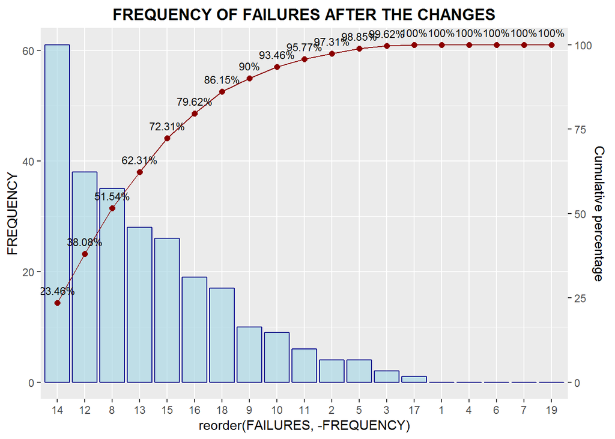

```r
num_failures_after = production_failures[, c(7, 28:46)] %>% filter(VERSION == 'AFTER')
num_failures_after[is.na(num_failures_after)] <- 0
num_failures_after <- num_failures_after[, -1]
num_failures_after <- data.frame(cbind(
  FAILURES = as.factor(gsub('_', '', colnames(production_failures[, c(28:46)]))),
  FREQUENCY = apply(num_failures_after, 2, sum)))
num_failures_after <- num_failures_after[order(-num_failures_after$FREQUENCY),]
num_failures_after <- num_failures_after %>% mutate(
  CUM_FAILURES = cumsum(FREQUENCY),
  CUM_PERC = round((CUM_FAILURES / sum(FREQUENCY) * 100), 2)
)

# Plotting the occurrences
ggplot(num_failures_after, aes(x = reorder(FAILURES, -FREQUENCY))) +
  geom_col(aes(y = FREQUENCY), fill = 'lightblue', color = 'darkblue', alpha = 0.7, group = 1) +
  ggtitle('FREQUENCY OF FAILURES AFTER THE CHANGES') +
  geom_line(aes(y = CUM_PERC*61/100), group = 2, color = 'darkred') +
  geom_point(aes(y = CUM_PERC*61/100), group = 2, shape = 21, color = 'darkred', fill = 'darkred', size = 2) +
  geom_text(aes(y = CUM_PERC*61/100, label = paste(CUM_PERC, '%', sep = '')), vjust = -1, size = 3) +
  scale_y_continuous(sec.axis = sec_axis(~.*100/61, name = 'Cumulative percentage'), limits = c(0, 61)) +
  theme(plot.title = element_text(vjust = 0.5, hjust = 0.5, face = 'bold'))
```

**Even though only the mean of performance can’t be enough to make decisions, it’s a simple way to check the evolution between before and after modifications.**

## Mean of Performance before and after changes

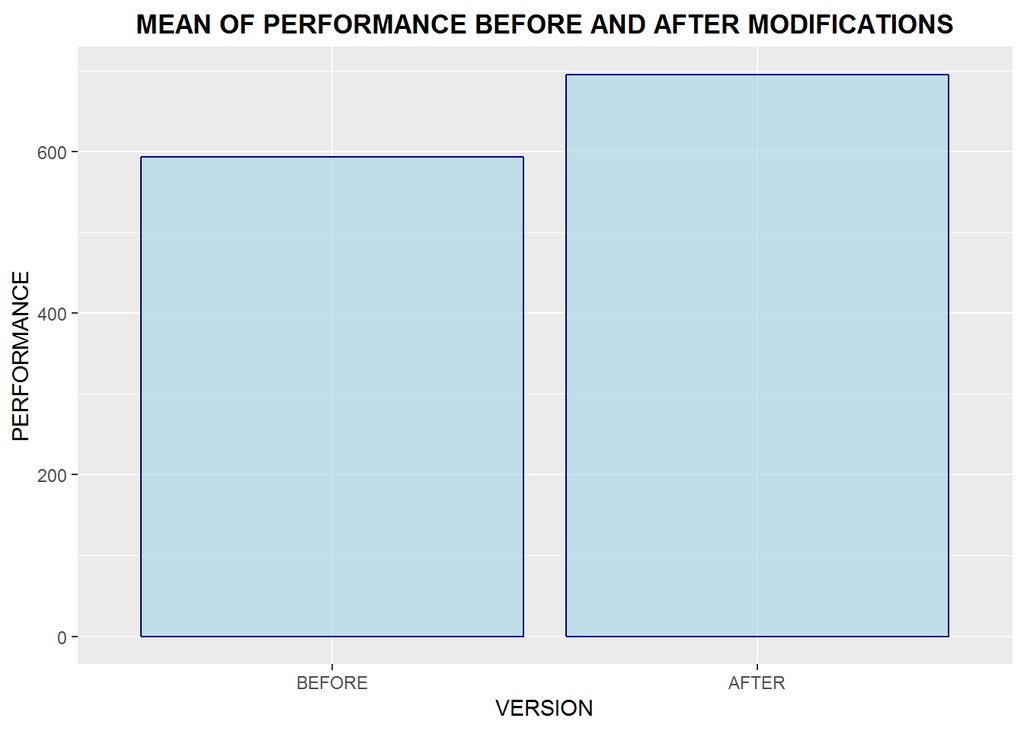

```r
ggplot(distinct(production_failures %>%
           group_by(VERSION) %>%
           mutate(PERFORMANCE = mean(PERFORMANCE)) %>%
           select(VERSION, PERFORMANCE),
         VERSION, .keep_all = T)) +
  geom_col(aes(x = VERSION, y = PERFORMANCE), fill = 'lightblue', color = 'darkblue', alpha = 0.7) +
  ggtitle('MEAN OF PERFORMANCE BEFORE AND AFTER MODIFICATIONS') +
  theme(plot.title = element_text(vjust = 0.5, hjust = 0.5, face = 'bold'))
```

**As expected, the mean of performance after modifications is higher than before**  
Function to plot the comparisons of performance between before and after

```r
compare_performances <- function(df, variable){
  target <- parse_quosure(variable) #quo
  # Listing the occurrences of variable to be compared
  list_to_compare <- as.vector(df[, variable])

  lapply(list_to_compare, function(x){
    before = ggplot(df %>% filter(!!target == x), aes(x = !!target)) +
      geom_col(aes(y = BEFORE), fill = 'lightblue', color = 'darkblue', alpha = 0.7) +
      ggtitle('PERFORMANCE BEFORE CHANGES') +
      geom_text(aes(y = BEFORE, label = round(BEFORE)), vjust = -0.5, size = 3) +
      theme(plot.title = element_text(vjust = 0.5, hjust = 0.5, face = 'bold')) +
      ylim(0, if_else(max(df$BEFORE) > max(df$AFTER), max(df$BEFORE), max(df$AFTER)))

    after = ggplot(df %>% filter(!!target == x), aes(x = !!target)) +
      geom_col(aes(y = AFTER), fill = 'lightblue', color = 'darkblue', alpha = 0.7) +
      ggtitle('PERFORMANCE AFTER CHANGES') +
      geom_text(aes(y = AFTER, label = round(AFTER)), vjust = -0.5, size = 3) +
      theme(plot.title = element_text(vjust = 0.5, hjust = 0.5, face = 'bold')) +
      ylim(0, if_else(max(df$BEFORE) > max(df$AFTER), max(df$BEFORE), max(df$AFTER)))

    grid.arrange(before, after, ncol = 2)
  })
}
```

## Mean of Performance before and after changes by product

```r
product_performance <- dcast(distinct(production_failures %>%
                                        group_by(PRODUCT, VERSION) %>%
                                        mutate(PERFORMANCE = mean(PERFORMANCE)) %>%
                                        select(PRODUCT, VERSION, PERFORMANCE),
                                      PRODUCT, VERSION, PERFORMANCE, .keep_all = T),
                             PRODUCT ~ VERSION)
```

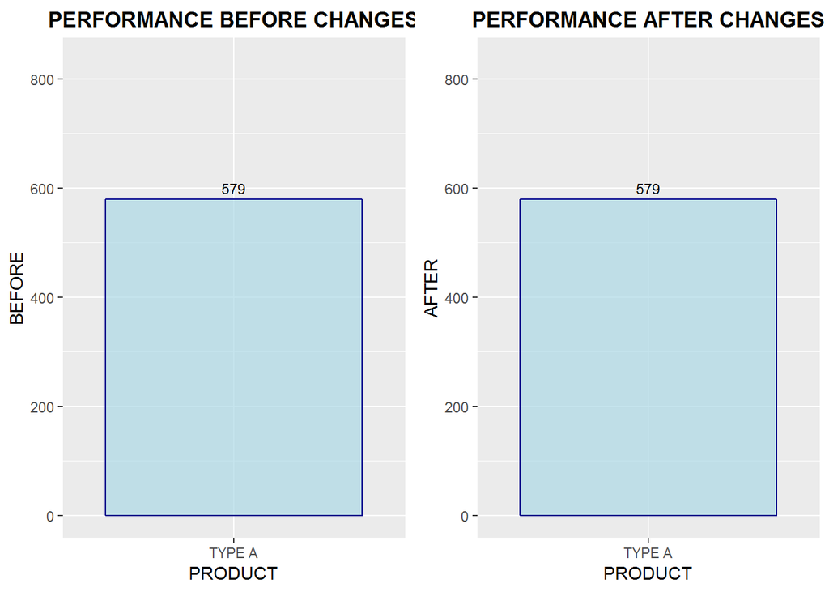

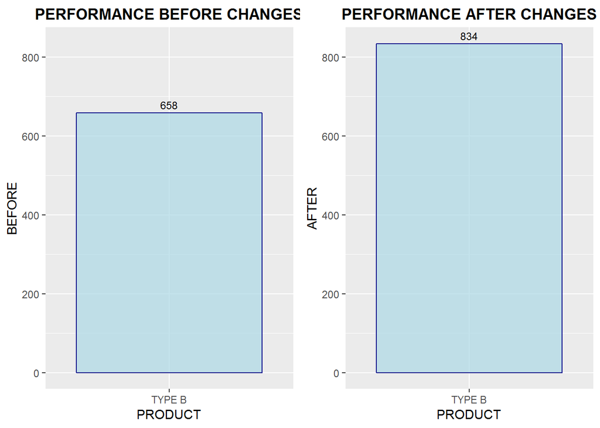

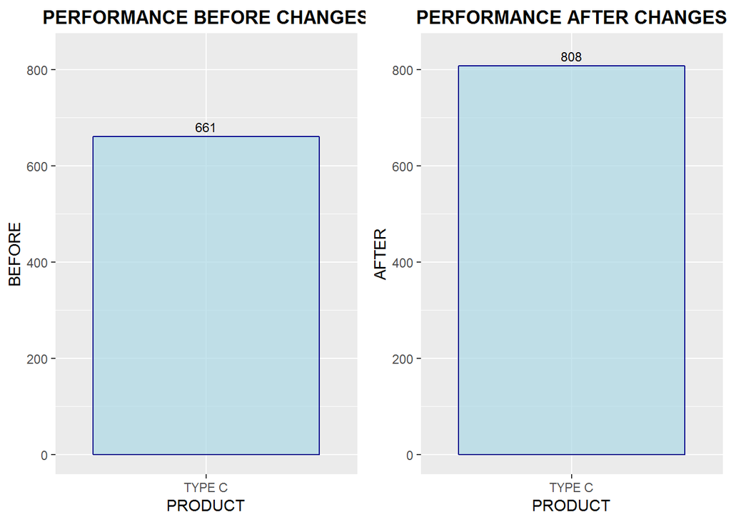

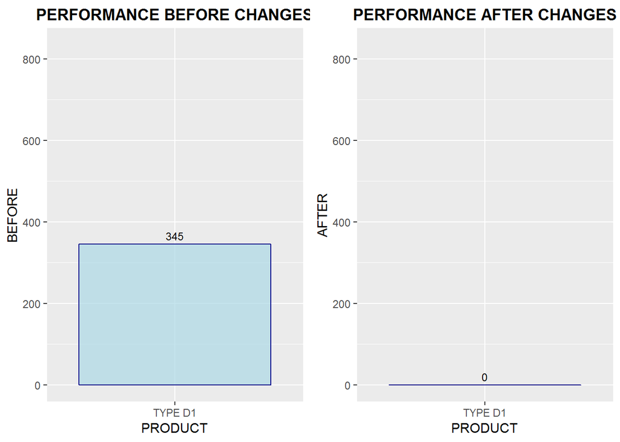

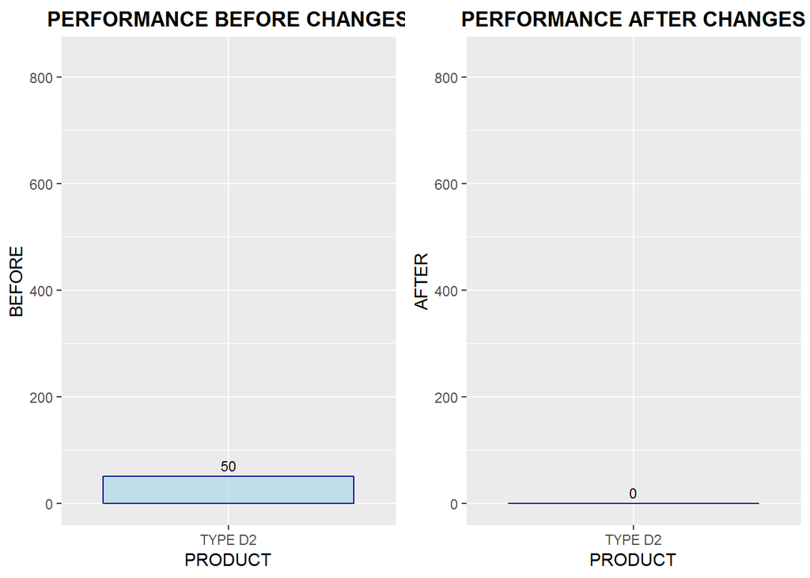

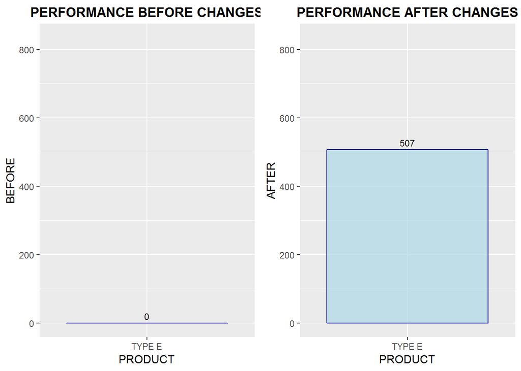

```r
# Replacing NA values with 0
product_performance[is.na(product_performance)] <- 0
# Calculating the evolution of performance for products that was produced both before and after changes
product_performance <- product_performance %>%
  mutate(DIF_PERFORMANCE = if_else(BEFORE == 0 | AFTER == 0, 0, AFTER - BEFORE),
         STATUS_EVOLUTION = if_else(DIF_PERFORMANCE > 0, 1, -1))
# Plotting the performances
compare_performances(product_performance, 'PRODUCT')
```

```r
product_performance
```

[output not shown]

**Having 0 performance, it means that the production don’t repeat for both versions.**  
**Either it stoped the production after changes or it started the production.**  
**But keeping these products in the dataset is quite important to check the variation of performances.**

## Checking the evolution between products

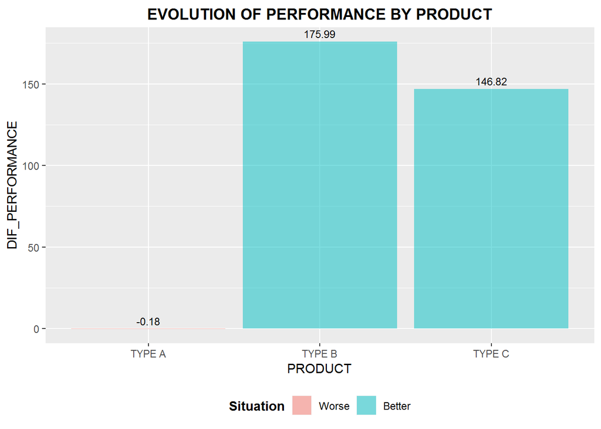

```r
ggplot(product_performance %>% filter(DIF_PERFORMANCE != 0)) +
  geom_col(aes(x = PRODUCT,
               y = DIF_PERFORMANCE,
               fill = factor(STATUS_EVOLUTION, labels = c('Worse', 'Better'))), alpha = 0.5) +
  ggtitle('EVOLUTION OF PERFORMANCE BY PRODUCT') +
  labs(fill = 'Situation') +
  geom_text(aes(x = PRODUCT, y = DIF_PERFORMANCE, label = round(DIF_PERFORMANCE, 2)), vjust = -0.5, size = 3) +
  theme(plot.title = element_text(vjust = 0.5, hjust = 0.5, face = 'bold'),
        legend.position = 'bottom',
        legend.title = element_text(face = 'bold'))
```

**Between the products with production before and after changes, only TYPE A got worse.**  
**List of products which has gotten worse**

```r
worse_products <- as.vector(unlist(product_performance %>% filter(DIF_PERFORMANCE < 0) %>% select(PRODUCT)))
```

**List of products which has improved**

```r
best_products <- as.vector(unlist(product_performance %>% filter(DIF_PERFORMANCE > 0) %>% select(PRODUCT)))
```

## MEAN OF PERFORMANCE BEFORE AND AFTER CHANGES BY MACHINE

```r
machine_performance <- dcast(distinct(production_failures %>%
                                        group_by(MACHINE, VERSION) %>%
                                        mutate(PERFORMANCE = mean(PERFORMANCE)) %>%
                                        select(MACHINE, VERSION, PERFORMANCE),
                                      MACHINE, VERSION, PERFORMANCE, .keep_all = T),
                             MACHINE ~ VERSION)
```

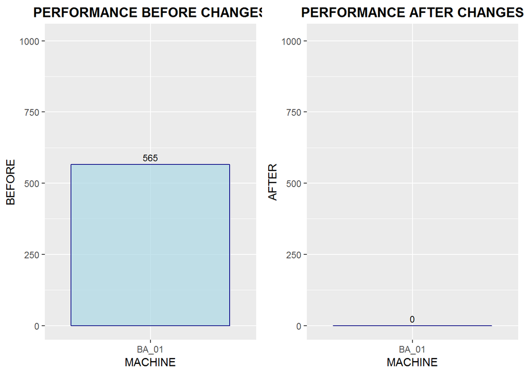

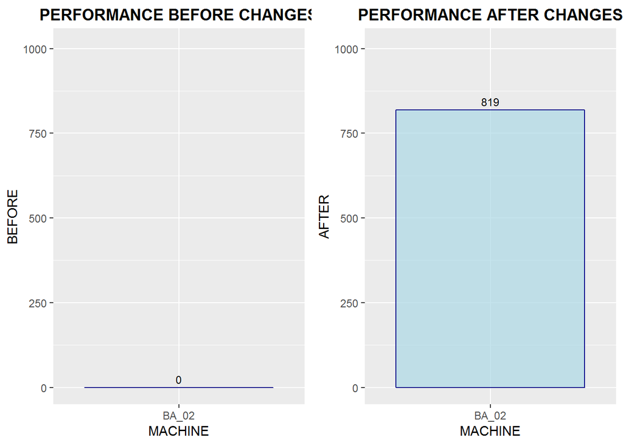

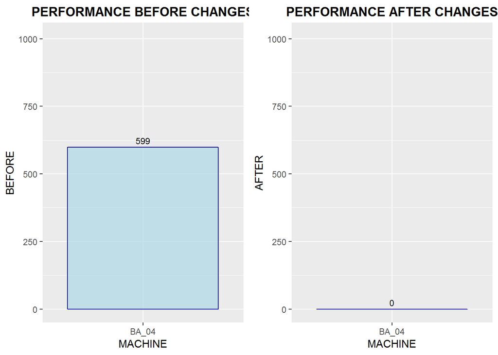

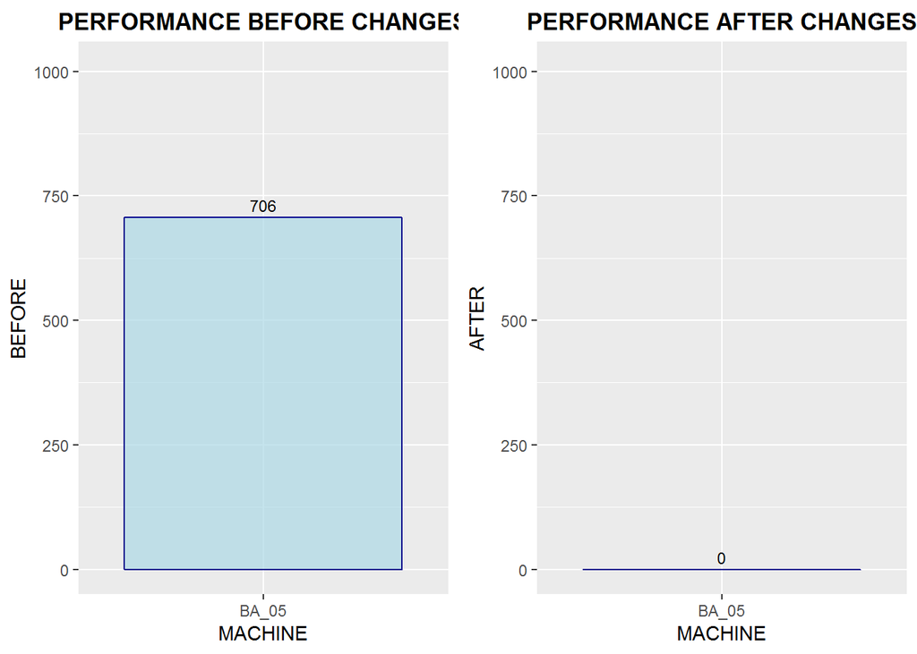

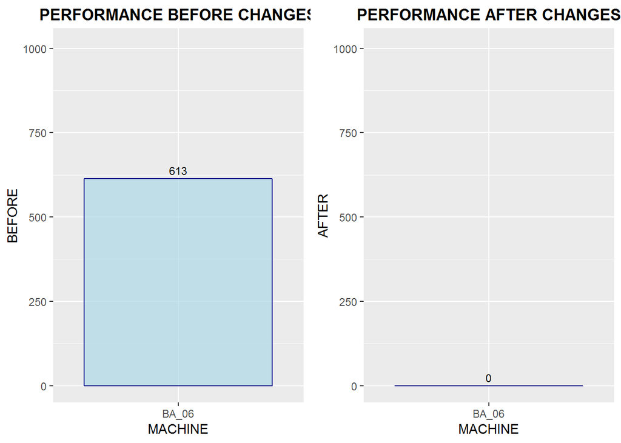

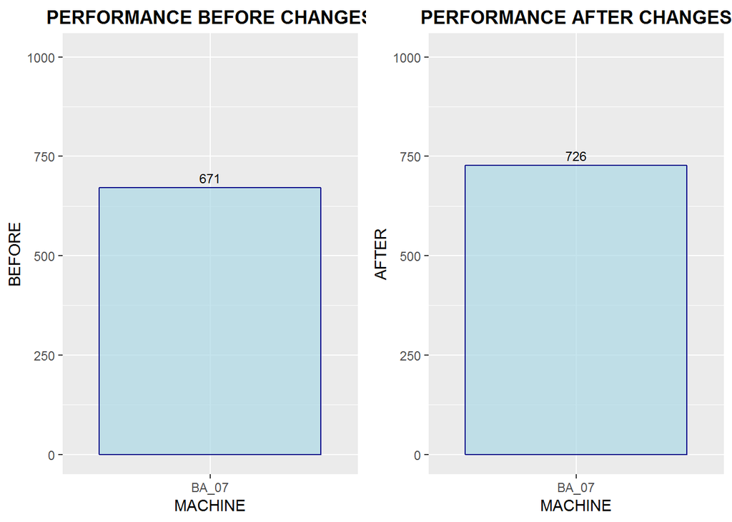

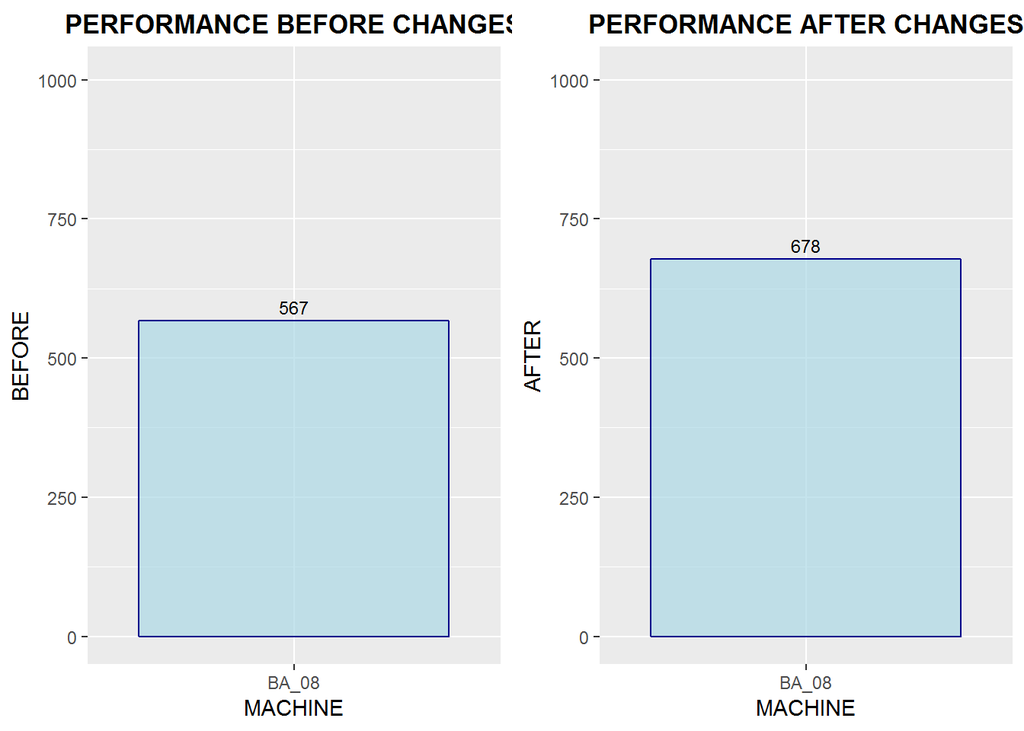

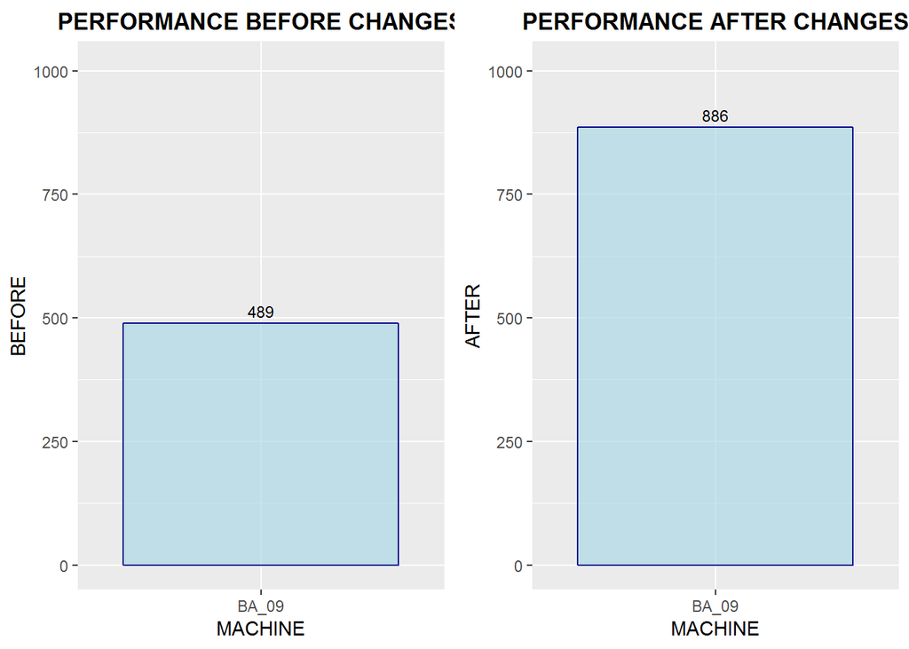

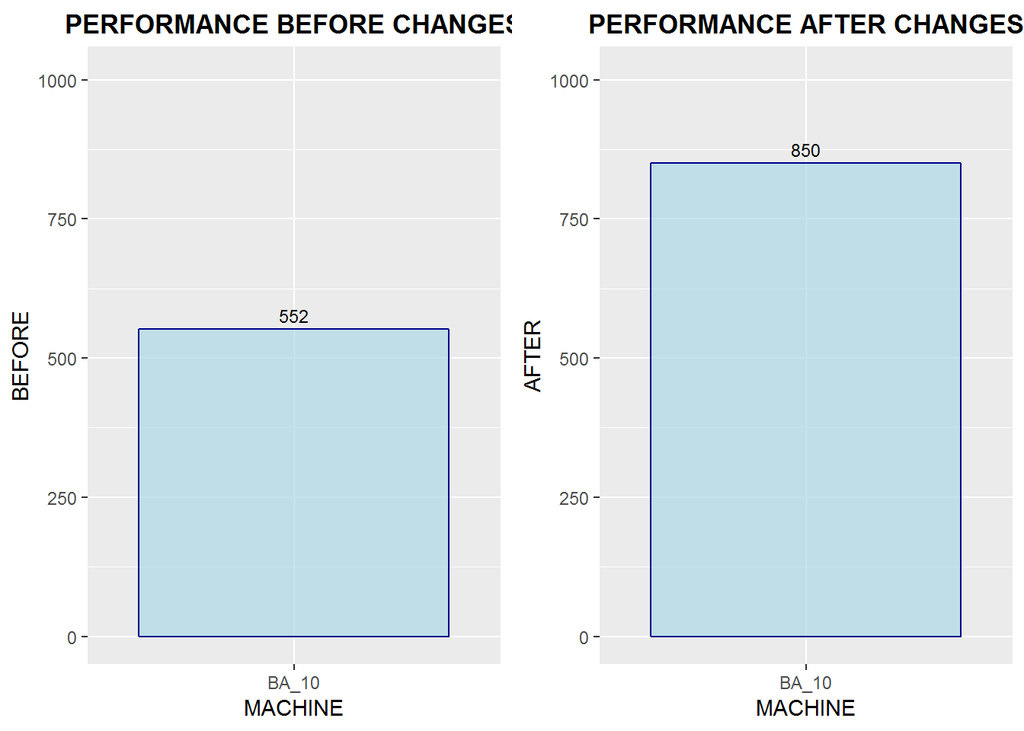

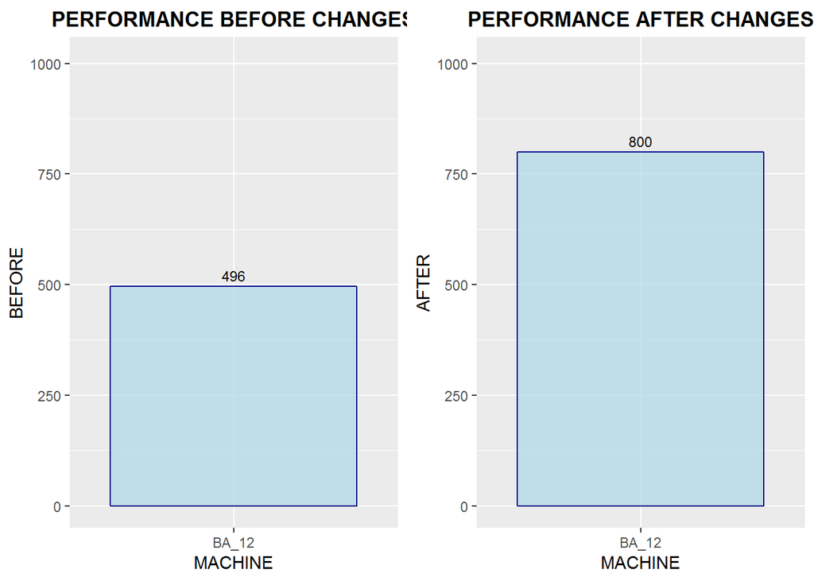

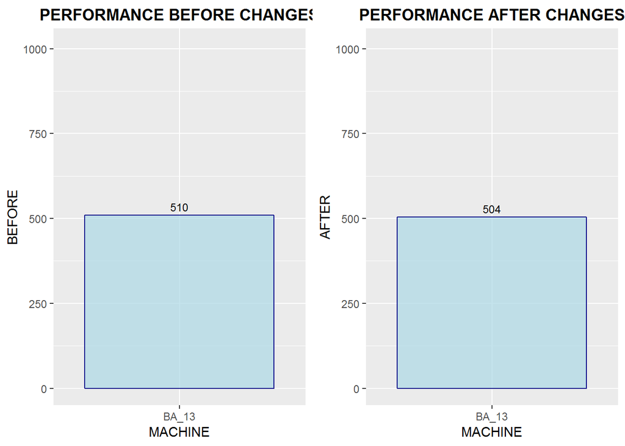

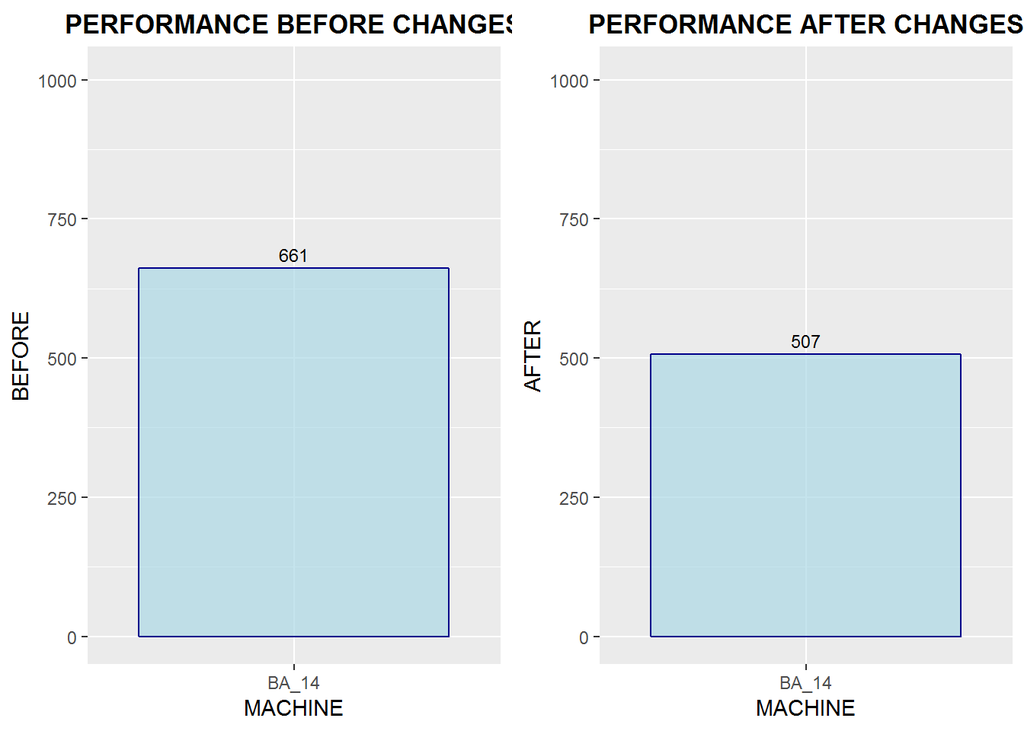

[12 more figures not shown]

```r
# Replacing NA values with 0
machine_performance[is.na(machine_performance)] <- 0
# Calculating the evolution of performance for machines that was produced both before and after changes
machine_performance <- machine_performance %>%
  mutate(DIF_PERFORMANCE = if_else(BEFORE == 0 | AFTER == 0, 0, AFTER - BEFORE),
         STATUS_EVOLUTION = if_else(DIF_PERFORMANCE > 0, 1, -1))
# Plotting the performances
compare_performances(machine_performance, 'MACHINE')
```

**Having 0 of performance, it means that the production wont repeat for both versions.**  
**Either it stoped the production after changes or it started the production.**  
**But keeping these machines in the dataset is quite important to check the variation of performances.**

## Checking the evolution between machines

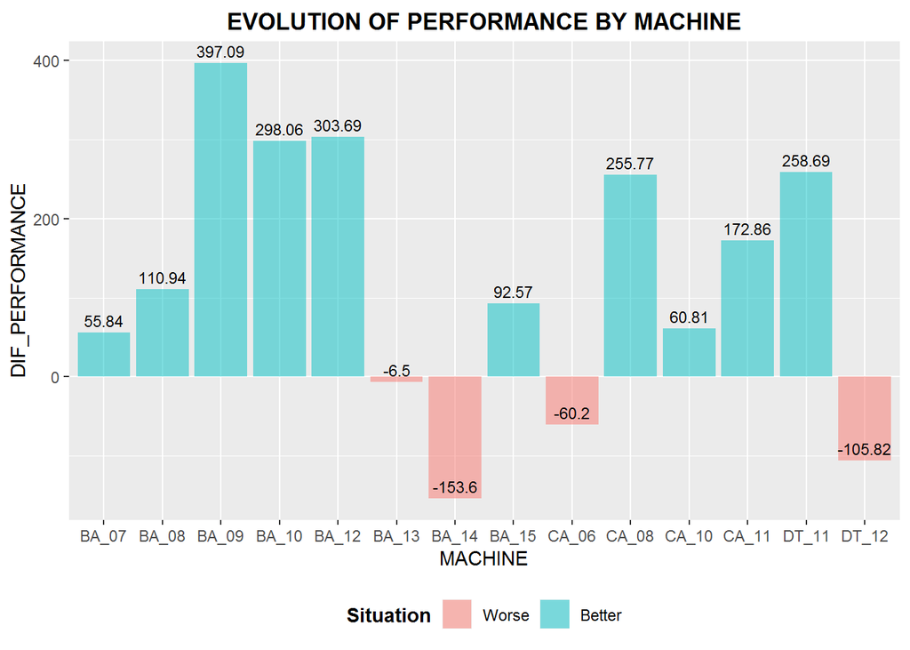

```r
ggplot(machine_performance %>% filter(DIF_PERFORMANCE != 0)) +
  geom_col(aes(x = MACHINE,
               y = DIF_PERFORMANCE,
               fill = factor(STATUS_EVOLUTION, labels = c('Worse', 'Better'))), alpha = 0.5) +
  ggtitle('EVOLUTION OF PERFORMANCE BY MACHINE') +
  labs(fill = 'Situation') +
  geom_text(aes(x = MACHINE, y = DIF_PERFORMANCE, label = round(DIF_PERFORMANCE, 2)), vjust = -0.5, size = 3) +
  theme(plot.title = element_text(vjust = 0.5, hjust = 0.5, face = 'bold'),
        legend.position = 'bottom',
        legend.title = element_text(face = 'bold'))
```

**List of machines which has gotten worse**

```r
worse_machines <- as.vector(unlist(machine_performance %>% filter(DIF_PERFORMANCE < 0) %>% select(MACHINE)))
```

**List of machines which has improved**

```r
best_machines <- as.vector(unlist(machine_performance %>% filter(DIF_PERFORMANCE > 0) %>% select(MACHINE)))
```

## Checking what machines have produced the worse products

```r
demand_by_machine_worse_products <- dcast(distinct(production_failures %>%
           filter(PRODUCT %in% worse_products) %>%
           group_by(PRODUCT, MACHINE, VERSION) %>%
           mutate(PRODUCTION = sum(LENGTH)) %>%
           select(PRODUCT, MACHINE, VERSION, PRODUCTION),
         MACHINE, VERSION, .keep_all = T),
      MACHINE + PRODUCT ~ VERSION)
demand_by_machine_worse_products[is.na(demand_by_machine_worse_products)] <- 0
demand_by_machine_worse_products %>% mutate(DIF_DEMAND = if_else(BEFORE > AFTER, 'REDUCED', 'INCREASED'))
```

```
##    MACHINE PRODUCT BEFORE AFTER DIF_DEMAND
## 1    BA_01  TYPE A  20290     0    REDUCED
## 2    BA_04  TYPE A   9360     0    REDUCED
## 3    BA_05  TYPE A   6835     0    REDUCED
## 4    BA_06  TYPE A  24036     0    REDUCED
## 5    BA_07  TYPE A  40180  8073    REDUCED
## 6    BA_08  TYPE A  40334 11267    REDUCED
## 7    BA_09  TYPE A  16851     0    REDUCED
## 8    BA_10  TYPE A  25855     0    REDUCED
## 9    BA_12  TYPE A  15908  4800    REDUCED
## 10   BA_15  TYPE A  11300 10462    REDUCED
## 11   DT_11  TYPE A  36457     0    REDUCED
## 12   DT_12  TYPE A  83804 29557    REDUCED
```

**As checked above, all the machines that produced the worse products have reduced the demand.**  
**There are at least two basic conclusions:**  
**1st:** The machines have not to do with the descreasement of the mean of performance  
**2nd:** As shorter the products are, as more it’s fails

To test this second one, it’s important to check if the demand by machine of the best products have increased.

```r
demand_by_machine_best_products <- dcast(distinct(production_failures %>%
                                                    filter(PRODUCT %in% best_products) %>%
                                                    group_by(PRODUCT, MACHINE, VERSION) %>%
                                                    mutate(PRODUCTION = sum(LENGTH)) %>%
                                                    select(PRODUCT, MACHINE, VERSION, PRODUCTION),
                                                  MACHINE, VERSION, .keep_all = T),
                                         MACHINE + PRODUCT ~ VERSION)
demand_by_machine_best_products[is.na(demand_by_machine_best_products)] <- 0
demand_by_machine_best_products <- demand_by_machine_best_products %>%
  mutate(DIF_DEMAND = if_else(BEFORE > AFTER, 'REDUCED', 'INCREASED'))
kable(table(demand_by_machine_best_products$DIF_DEMAND))
```

| Var1 | Freq |
| --- | --- |
| INCREASED | 9 |
| REDUCED | 12 |

**In general, the most cases show that the demand has decreased.**

But to assume it’s true, it’s important to measure the difference of length mean.

```r
demand_by_machine_best_products <- dcast(distinct(production_failures %>%
                                                    filter(PRODUCT %in% best_products) %>%
                                                    group_by(PRODUCT, MACHINE, ID, VERSION) %>%
                                                    mutate(PRODUCTION = mean(LENGTH)) %>%
                                                    select(PRODUCT, MACHINE, ID, VERSION, PRODUCTION),
                                                  MACHINE, VERSION, .keep_all = T),
                                         MACHINE + ID + PRODUCT ~ VERSION)
kable(demand_by_machine_best_products) %>%
  kable_styling(bootstrap_options = c('striped', 'hover', 'condensed'),
                font_size = 9)
```

| MACHINE | ID | PRODUCT | BEFORE | AFTER |
| --- | --- | --- | --- | --- |
| BA_02 | 11-1078/90 | TYPE B | NA | 1020 |
| BA_02 | 11-1078/91 | TYPE B | NA | 1014 |
| BA_08 | 11-0966/93 | TYPE B | NA | 513 |
| BA_09 | 10-2828/90 | TYPE B | 286 | NA |
| BA_09 | 11-0966/90 | TYPE B | NA | 1020 |
| BA_09 | 11-0966/91 | TYPE B | NA | 1020 |
| BA_09 | 11-0966/92 | TYPE B | NA | 1020 |
| BA_09 | 11-1087/90 | TYPE B | NA | 1122 |
| BA_09 | 11-1087/91 | TYPE B | NA | 1032 |
| BA_10 | 11-0975/90 | TYPE B | 1020 | NA |
| BA_10 | 11-0975/91 | TYPE B | NA | 1020 |
| BA_10 | 11-0975/92 | TYPE B | 1020 | NA |
| BA_10 | 11-0975/93 | TYPE B | 547 | NA |
| BA_13 | 11-1018/90 | TYPE B | 1020 | NA |
| BA_13 | 11-1018/91 | TYPE B | NA | 1007 |
| BA_14 | 11-0192/90 | TYPE C | 1017 | NA |
| BA_14 | 11-0192/91 | TYPE C | 1203 | NA |
| BA_17 | 11-1088/90 | TYPE C | NA | 1043 |
| CA_05 | 10-2828/91 | TYPE B | 519 | NA |
| CA_05 | 11-0191/90 | TYPE C | 1020 | NA |
| CA_05 | 11-0191/91 | TYPE C | 1031 | NA |
| CA_06 | 10-2803/90 | TYPE C | 1010 | NA |
| CA_06 | 11-1020/90 | TYPE C | NA | 1020 |
| CA_06 | 11-1020/91 | TYPE C | NA | 1137 |
| CA_06 | 11-1090/90 | TYPE B | 1122 | NA |
| CA_06 | 11-1090/91 | TYPE B | NA | 1077 |
| CA_08 | 11-0958/90 | TYPE B | NA | 1020 |
| CA_08 | 11-0958/91 | TYPE B | NA | 1006 |
| CA_08 | 11-0969/90 | TYPE B | 1020 | NA |
| CA_08 | 11-0969/91 | TYPE B | 1020 | NA |
| CA_08 | 11-1080/90 | TYPE B | 480 | NA |
| CA_08 | 11-1080/91 | TYPE B | 916 | NA |
| CA_10 | 11-1017/90 | TYPE B | 1020 | NA |
| CA_10 | 11-1017/91 | TYPE B | 989 | NA |
| CA_10 | 11-1019/90 | TYPE C | NA | 1020 |
| CA_10 | 11-1019/91 | TYPE C | NA | 1175 |
| CA_11 | 11-1015/90 | TYPE B | NA | 1020 |
| CA_11 | 11-1015/91 | TYPE B | 1025 | NA |
| CA_12 | 11-1026/90 | TYPE C | NA | 1020 |
| CA_12 | 11-1026/92 | TYPE C | NA | 1195 |
| CA_12 | 11-1093/90 | TYPE B | NA | 1122 |
| CA_12 | 11-1093/91 | TYPE B | NA | 892 |
| CA_13 | 10-2019/91 | TYPE B | 1075 | NA |
| CA_15 | 10-2805/90 | TYPE C | 1002 | NA |
| DT_11 | 11-0956/90 | TYPE B | NA | 136 |
| DT_11 | 11-0956/91 | TYPE B | NA | 884 |
| DT_11 | 11-0956/92 | TYPE B | NA | 1020 |
| DT_11 | 11-0956/93 | TYPE B | NA | 1526 |
| DT_11 | 11-0973/90 | TYPE B | NA | 940 |
| DT_11 | 11-0973/91 | TYPE B | NA | 1020 |
| DT_11 | 11-0973/92 | TYPE B | NA | 1020 |
| DT_11 | 11-0973/93 | TYPE B | NA | 587 |
| DT_11 | 11-1089/90 | TYPE C | 1136 | NA |
| DT_11 | 11-1095/90 | TYPE C | 825 | NA |

## Calculating the difference between length mean before and after changes

```r
mean(demand_by_machine_best_products$AFTER, na.rm = T)-mean(demand_by_machine_best_products$BEFORE, na.rm = T)
```

```
## [1] 62.20337
```

**Even it’s shown that the products have incresead the length by unit, 62 meters aren’t enough to affirm that the length has impact to the number of failures.**  
To finally check if there are a correlation between the length of products and number of failures, it will be calculated the correlation coefficient.

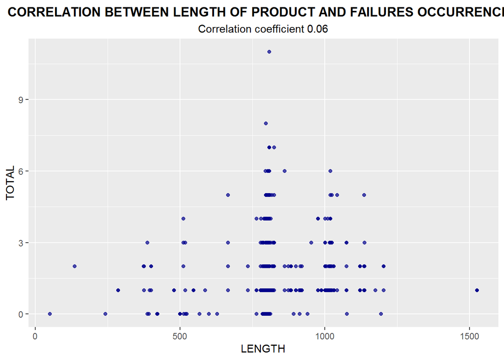

```r
ggplot(production_failures) +
  geom_point(aes(x = LENGTH, y = TOTAL), fill = 'lightblue', color = 'darkblue', alpha = 0.7) +
  ggtitle('CORRELATION BETWEEN LENGTH OF PRODUCT AND FAILURES OCCURRENCES') +
  labs(subtitle = paste('Correlation coefficient',
                        round(cor(production_failures$LENGTH,
                            production_failures$TOTAL,
                            method = c('pearson', 'kendall', 'spearman')),2))) +
  theme(plot.title = element_text(vjust = 0.5, hjust = 0.5, face='bold'),
        plot.subtitle = element_text(vjust = 0.5, hjust = 0.5))
```

**With a correlation coefficient close to 0, it’s proved that there aren’t a a strong correlation between the length of the product with the number of failures.**  
So, at this point, the first suggestion that the machines have not to do with the performance decreasement of the product TYPE A is being considered true, and the second one isn’t comproved.

## ANALYSIS OF FREQUENCE OF FAILURES BY SECTIONS OF THE PRODUCT.

Since the product can be measured by length, by analysing the number of failures per secction can bring up some insights that could help to understand if the failures occur more at the begin of the proccess, at the middle of the proccess or at the end of the proccess.

### Calculating the occurrences by secction of the product

Considering that the failures ID has a letter at the end, and this letters represent the secction of the product in a sequential order (A = begin, B = 2nd part, C = 3rd part, …) it may be used to calculate if the products have a tendence of more failures in a specific secction.

```r
failures_by_section <- failures_original
failures_by_section <- failures_by_section %>% mutate(ID = str_extract(ID, '\\w$'))
```

Checking unique values

```r
unique(failures_by_section$ID)
```

```
##  [1] "D" "C" "B" "A" "E" "F" "H" "I" "1" "J" "G" "0" "K"
```

0 and 1 should not be part of this analysis, because it’s due to products that aren’t splitted

```r
failures_by_section <- failures_by_section %>% filter(ID != '0' & ID != '1')
```

## Checking the frequency by secction

```r
kable(table(failures_by_section$ID))
```

| Var1 | Freq |
| --- | --- |
| A | 159 |
| B | 133 |
| C | 128 |
| D | 130 |
| E | 31 |
| F | 16 |
| G | 16 |
| H | 23 |
| I | 14 |
| J | 18 |
| K | 5 |

**The secctions between A and D has the most number of occurrences. It regards to the most products are splitted into only four secctions.**  
To guarantee a better annalysis, it’s being considered to discard secctions above D

```r
failures_by_section <- failures_by_section %>% filter(
  ID == 'A' | ID == 'B' | ID == 'C' | ID == 'D'
)
```

## Counting the occurrence of failures by secction

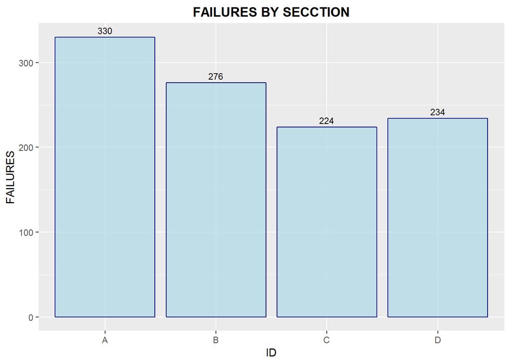

```r
failures_by_section <- distinct(
  failures_by_section %>%
    group_by(ID) %>%
    mutate(FAILURES = sum(TOTAL)) %>%
    select(ID, FAILURES),
  ID, .keep_all = T)

# Plotting the failures by secction
ggplot(failures_by_section) +
  geom_col(aes(x = ID, y = FAILURES), fill = 'lightblue', color = 'darkblue', alpha = 0.7) +
  ggtitle('FAILURES BY SECCTION') +
  geom_text(aes(x = ID, y = FAILURES, label = FAILURES), vjust = -0.5, size = 3) +
  theme(plot.title = element_text(vjust = 0.5, hjust = 0.5, face = 'bold'))
```

**As shown in the plot in general the most failures are at the begin of the products.**  
**At this point it will be considered that it important to check if the setup of the machines have to do with this occurrences.**

## Checking if the performance has improved with the changes

```r
performance_comparison <- machine_performance %>%
  filter(STATUS_EVOLUTION == 1) %>%
  select(MACHINE, BEFORE, AFTER)
```

## Testing the normality of the distribution of performance before and after changes

```r
shapiro.test(performance_comparison$BEFORE)
```

```
##
##  Shapiro-Wilk normality test
##
## data:  performance_comparison$BEFORE
## W = 0.92412, p-value = 0.3926
```

```r
shapiro.test(performance_comparison$AFTER)
```

```
##
##  Shapiro-Wilk normality test
##
## data:  performance_comparison$AFTER
## W = 0.97018, p-value = 0.8925
```

**Since the both distribution was tested as normal, and the machines are the same, so the hypothesis test that will be reproduced is t test for parametric statistic.**

**The alternative hypothesis is:** (mean of AFTER - mean of BEFORE) > 0  
**The confidence level is:** 0.95

```r
t.test(performance_comparison$AFTER, performance_comparison$BEFORE,
       alternative = 'greater',
       paired = T)
```

```
##
##  Paired t-test
##
## data:  performance_comparison$AFTER and performance_comparison$BEFORE
## t = 5.3593, df = 9, p-value = 0.0002284
## alternative hypothesis: true difference in means is greater than 0
## 95 percent confidence interval:
##  132.0073      Inf
## sample estimates:
## mean of the differences
##                200.6317
```

**With a p-value reaching less than 0.05 the alternative hypothesis has been accepted, confirming that thechanges have made the difference in the process.**

## Plotting the results

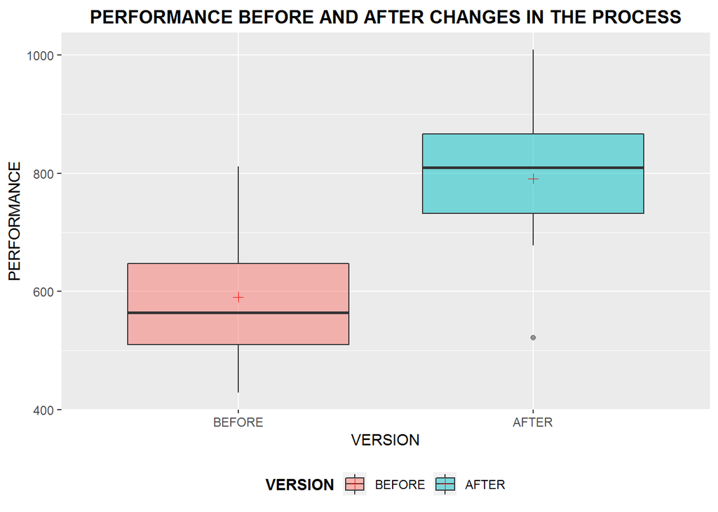

```r
performance_comparison <- melt(performance_comparison,
     id.vars = c('MACHINE'),
     variable.name = 'VERSION',
     value.name = 'PERFORMANCE',
     variable.factor = T)

ggplot(performance_comparison, aes(x = VERSION, y = PERFORMANCE, fill = VERSION)) +
  geom_boxplot(alpha = 0.5) +
  ggtitle('PERFORMANCE BEFORE AND AFTER CHANGES IN THE PROCESS') +
  stat_summary(fun.y = mean, colour = 'red', geom = 'point', shape = 3, size = 2) +
  theme(plot.title = element_text(vjus = 0.5, hjust = 0.5, face = 'bold'),
        legend.position = 'bottom',
        legend.title = element_text(face = 'bold'))
```

## FINAL CONCLUSIONS

**1 -** There’s a evidence that probably the changes have contributed to reduce the frequency of the failures 4, 3, 2, 5 and 17.  
**2 -** The failures aren’t centered in specific machines.  
**3 -** The most failures are concentrated at the beginning of the products.  
**4 -** The changes have done difference and contributed to improve the performance.